Created and prepared by Term 2 LT6: Alenton, Avila, Cruz, Obiso, Susmerano, Wong

[figure not shown]

# Executive Summary

The COVID-19 pandemic ushered in a new era of *new normal* which forced everyone to contend with lockdowns, wearing of face masks, vaccine fears, misinformation, and a whole lot more. Working professionals switched to working from home; effectively cutting off face-to-face interactions with one's social circle, and removing work boundaries which resulted into longer work hours. Those working in the gig and informal economy found themselves in precarious positions as to the source of their incomes. It's no wonder that people's mental health are affected; and worse, mental illness such as depression and anxiety are on the rise.

Ideas such as taking care of one's mental health has re-emerged; and are gaining traction and wide recognition. People have turned online to look for ways on how to ease and take care of one's mental health. `Inquirer.net` is one such source of information. As such, **the team has brought it on themselves to create a repository of `Inquirer.net` articles related to mental health.**

The team then evaluated the model and found that **from the plots generated, there was an indication of a negative correlation between precision and recall in the predictions because the closer precision was to 1, recall moves closer to 0 and vice-versa.**

# Introduction

Mental health pertains to the emotional, psychological, and social well-being of a person. The state of one's mental health influences how one thinks, feels, and acts. It helps one determine how to handle stress, socialize with others, and generally make choices (Mental Health, 2022).

When one's mental health is great, one would usually exude confidence, work productively, and effectively cope with daily stressors; basically they're out and about realizing their full potential. On the other hand, when one experiences mental health problems, they experience a myriad of things that makes day-to-day living difficult. Such as ruminating in negative thoughts, lacking of energy and/or overall motivation, feeling distressed, helpless, and/or dejected, and so much more. Mental health problems may cause mental illness, such as anxiety and depression, which impacts all facets of one's life.

As the COVID-19 pandemic continuous to ravage the world and upend everyone's lives, the World Health Organization has found that **the COVID-19 pandemic had triggered a 25% increase in prevalence of anxiety and depression worldwide, with young people and women worse hit** (World Health Organization, 2022).

Therefore, now more than ever, people are starting to take stock and become interested in not just their physical health but also their mental health. With all these in mind, the team has brought it on themselves to create a repository of articles, starting from Inquirer.net, that provides information and insights about caring for one's mental health.

## Problem Statement

Two years and counting into the COVID-19 pandemic, the weight of it has now definitely affected everyone's mental health in one way or another. As such, the team has set out to **create a repository of Inquirer.net articles related to lifestyle**. And among these articles, the team wanted to **identify which ones were most relevant to *mental health***.

## Objective

To create a repository of Inquirer.net articles, related to lifestyle, that would allow one to identify articles that are relevant to the topic of **mental health** using methods such as webscraping, information retrieval, and model evaluation.

## Data Description

The data was scraped from two sources:

- lifestyle.inquirer.net
- Articles taken from Inquirer.net's search engine using the keyword `mental_health`

both of which were from `inquirer.net`.

These were then combined to create a new dataset which retained the following information:

- title: the article's title as seen on the website
- link: the url that leads to the specific article
- publish_time: the date when the article was published
- text: text from the whole article
- category: category tags of articles (e.g. fashion, human interest, beauty, culture, etc)

Webscraping methodology is discussed thoroughly in the third section of this paper: *Web scraping of the articles*.

In the interest of time and considering relevance, the team opted for the following scope and limitations:

## Methodology

The high-level methodology is composed of five steps which will be discussed in the next sections, and can be summarized using the following flowchart:

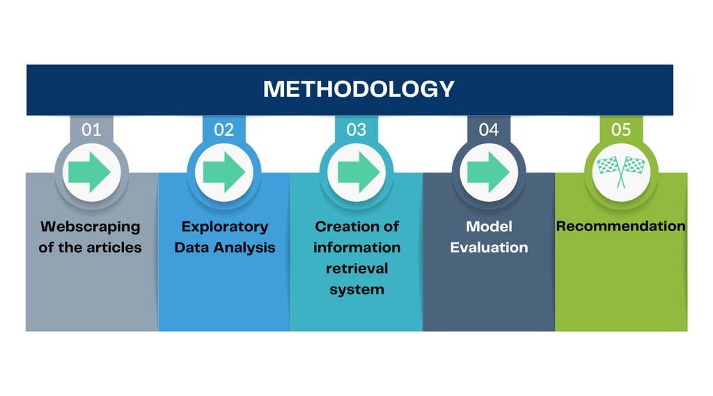

*Figure 1: Methodology*

# Web scraping of the articles

1. Scraped all articles from `lifestyle.inquirer.net`
2. Gathered all `mental_health` search results from the site's search engine.

**The following steps were undertaken to extract each dataset:**

- For all articles from `lifestyle.inquirer.net`:

`Lifestyle.inquirer.net` has seven categories on its website: *fashion, beauty, culture, travel, food, entertainment and human interest*. Each category contains articles. And for each article, some basic information was scraped; such as: _article_title, article_link, article_publish_time, article*text, and category*. These were then stored in a dataframe which was then used for further processing.

- For all articles resulting from a `mental_health` search from the site's search engine:

The keyword `mental_health` was used in the search engine which resulted to a list of related articles. Similar to the previous dataset, the basic information listed above was scraped and then stored in a dataframe. The reason for using the site's search engine was that there were mental health related articles which did not fall under any category in `lifestyle.inquirer.net`.

| Feature | Data Type |
| --- | --- |
| title | str |
| link | str |
| publish_time | str |
| text | str |
| category | str |

*Table 1: Information scraped from both datasets*

Information from both datasets was then stored to a .csv file: `lifestyle.csv` for articles from lifestyle.inquirer.net, and `mental_health_articles.csv` for articles resulting from searching the keyword ‘mental health’ using the website’s search engine.

**See `Web Scraping Inquirer.ipynb` for the web scraping code that generates `inquirer.csv` which is loaded in the following section.**

# Exploratory Data Analysis

| publish_time | title | link | mh_related |
| --- | --- | --- | --- |
| 2022-11-21 21:48:00 | Miss Earth bets now in Albay for preliminary competition; vow to protect environment | https://lifestyle.inquirer.net/433551/miss-earth-bets-now-in-albay-for-preliminary-competition-vow-to-protect-environment/ | 1 |
| 2022-11-21 15:48:00 | Listening Party: BTS Jung Kook enters his Shakira era with ‘Dreamers’ for the FIFA 2022 Soundtrack | https://lifestyle.inquirer.net/433510/listening-party-bts-jung-kook-enters-his-shakira-era-with-dreamers-for-the-fifa-2022-soundtrack/ | 0 |
| 2022-11-19 16:34:00 | ‘I’d like to, but my children won’t let me’ | https://lifestyle.inquirer.net/431933/id-like-to-but-my-children-wont-let-me/ | 1 |
| 2022-11-19 12:00:00 | Listening Party: Jin of BTS bids a brief farewell with the heart-felt ‘The Astronaut’ | https://lifestyle.inquirer.net/433123/listening-party-jin-of-bts-bids-a-brief-farewell-with-the-heart-felt-the-astronaut/ | 0 |
| 2022-11-18 13:48:00 | Listening Party: Rihanna’s ‘Lift Me Up’ is the perfect tribute to Chadwick Boseman | https://lifestyle.inquirer.net/433106/listening-party-rihannas-lift-me-up-is-the-perfect-tribute-to-chadwick-boseman/ | 0 |

**Table 2. Corpus of Articles in Lifestyle - Inquirer from 2018 to 2022.**  
These are the five most recent articles in Lifestyle - Inquirer labeled based on their relation to mental health.

Prior to performing further analysis, a quality check on the datasets was executed. The team found that **there were duplicates of some articles; these were then dropped** before combining everything into one dataset. In addition to these, **the team dropped articles with text that did not follow the ASCII format**. This was to be efficient with computing power and ensure that only readable texts were used. Lastly, **the column *category* was dropped** as not all articles had a category tag and it did not add value to the dataset. **All these data cleaning effectively trimmed the dataset down to 4,390 articles.**

No other EDA was conducted as the data that the team was dealing with were in text format rather than numerical values.

# Creation of Information Retrieval System

**Term frequency-inverse document frequency (TF-IDF) was created from the dataset**. The columns were then summed and sorted by value. This was to generate a world cloud to aid in the high level inspection of how related the generated words were to mental health before implementing the Information Retrieval (IR) system.

In order to create the information retrieval system, the team first defined the desired output from the database that would return mental health-related articles. Then, the representation of the texts within the dataset were aligned so that the exemplar that the team will enter in the repository could easily be matched.

## Functions

The team used `tfidf_vectorizer` to vectorize mental health health-related articles into a matrix of TF-IDF features. This was to allow the text to become suitable for future statistical analysis.

## Identify the words most relevant to mental health

The team **ranked the important mental health-related tokens** and **visualized their relevance through a word cloud**. The resulting wordcloud show the following words as the most frequent and relevant tokens:

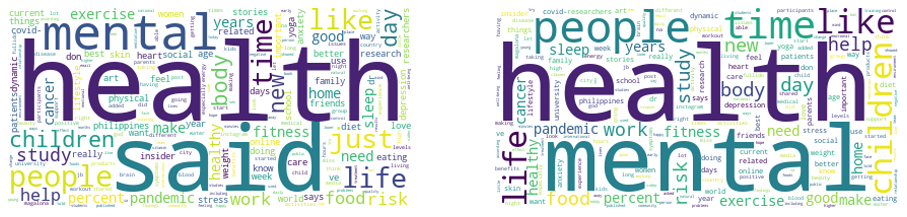

**Figure 2. Wordcloud of Mental Health Related Tokens.**  
On the left is the unfiltered word cloud and on the right is the wordcloud with the word "said" removed.

During the selection of these tokens, the team opted to remove the word `said` and treat it as a stop word due to the context of Inquirer as a news outlet. The news industry frequently uses a third-person narrative and includes citations that usually begins with the name of a related person and the word `said`. **Therefore, it is more likely to be a token inflated in frequency data source environment rather than its significance as a feature.**

## Vectorize the corpus

| health | mental | people | time | like | life | children | body | day | new | study | risk | help | food | work | pandemic |
| --- | --- | --- | --- | --- | --- | --- | --- | --- | --- | --- | --- | --- | --- | --- | --- |
| 0.0 | 0.000000 | 0.059922 | 0.000000 | 0.000000 | 0.000000 | 0.000000 | 0.0 | 0.000000 | 0.000000 | 0.0 | 0.0 | 0.038681 | 0.000000 | 0.037460 | 0.000000 |
| 0.0 | 0.000000 | 0.015012 | 0.042214 | 0.000000 | 0.000000 | 0.000000 | 0.0 | 0.016725 | 0.000000 | 0.0 | 0.0 | 0.000000 | 0.000000 | 0.000000 | 0.000000 |
| 0.0 | 0.031811 | 0.017876 | 0.050267 | 0.066034 | 0.066182 | 0.141584 | 0.0 | 0.000000 | 0.063505 | 0.0 | 0.0 | 0.000000 | 0.023838 | 0.022350 | 0.029794 |
| 0.0 | 0.000000 | 0.011302 | 0.000000 | 0.052187 | 0.000000 | 0.000000 | 0.0 | 0.012592 | 0.010038 | 0.0 | 0.0 | 0.029183 | 0.000000 | 0.014131 | 0.000000 |
| 0.0 | 0.000000 | 0.015127 | 0.028359 | 0.027940 | 0.018669 | 0.000000 | 0.0 | 0.000000 | 0.000000 | 0.0 | 0.0 | 0.000000 | 0.000000 | 0.000000 | 0.000000 |

`corpus_df` contains the articles in the form of vectors whose similarities can be measured using distance measures.

# Model Evaluation

In order to evaluate the performance of the model, the team measured the predictions made by the model for each class; whether it returned relevant or irrelevant text in its prediction.

To evaluate the information retrieval system, the team chose one mental health related exemplar to represent each year of published articles in the corpus:

- 2018, "Sleep: Less than 8 hours a night increases risk of depression"
- 2019, "5 ways to boost your mental health this year"
- 2020, "Your mind can heal your body"
- 2021, "Mental health and the power of asking for help"
- 2022, "Dealing with anxiety and depression? You are not alone"

It is also noteworthy that using domain knowledge, **the team observed that there were only a few articles in 2020 that were related and relevant to mental health**. In turn, this was interestingly reflected in the plots in section *6.3 Plot the Precision-Recall Curves*.

## The Exemplars

| publish_time | title | link | mh_related |
| --- | --- | --- | --- |
| 2022-04-01 17:42:00 | Dealing with anxiety and depression? You are not alone | https://lifestyle.inquirer.net/400049/dealing-with-anxiety-and-depression-you-are-not-alone/ | 1 |
| 2021-11-09 17:55:00 | Mental health and the power of asking for help | https://lifestyle.inquirer.net/391007/mental-health-and-the-power-of-asking-for-help/ | 1 |
| 2020-10-27 17:20:00 | Your mind can heal your body | https://lifestyle.inquirer.net/373496/your-mind-can-heal-your-body/ | 1 |
| 2019-01-14 18:20:00 | 5 ways to boost your mental health this year | https://lifestyle.inquirer.net/321055/5-ways-to-boost-your-mental-health-this-year/ | 1 |
| 2018-01-07 14:05:00 | Sleep: Less than 8 hours a night increases risk of depression | https://lifestyle.inquirer.net/283903/p2fb-sleep-less-8-hours-night-increases-risk-depression/ | 1 |

**Table 4. Exemplars of Mental Health Related Articles in Lifestyle - Inquirer from 2018 to 2022.**  
These are the five articles in Lifestyle - Inquirer most relevant to mental health per year.

## Retrieve the most relevant articles to the exemplar

A sample evaluation is shown below using the first article in the previous table.

| publish_time | title | link | mh_related |
| --- | --- | --- | --- |
| 2022-04-01 17:42:00 | Dealing with anxiety and depression? You are not alone | https://lifestyle.inquirer.net/400049/dealing-with-anxiety-and-depression-you-are-not-alone/ | 1 |
| 2022-07-01 15:09:00 | The dangers of romanticizing mental illness | https://lifestyle.inquirer.net/409480/the-dangers-of-romanticizing-mental-illness/ | 1 |
| 2021-10-03 19:41:00 | ‘End the stigma—all feelings are valid!’ | https://lifestyle.inquirer.net/389190/end-the-stigma-all-feelings-are-valid/ | 1 |
| 2021-06-18 12:34:00 | No health without mental health: A lesson from Globe, DepEd Tayo Naman! webinar | https://lifestyle.inquirer.net/384531/no-health-without-mental-health-a-lesson-from-globe-deped-tayo-naman-webinar/ | 1 |
| 2021-12-10 12:30:00 | ‘Thank you for being brave’: Readers respond to mental health stories | https://lifestyle.inquirer.net/392320/thank-you-for-being-brave-readers-respond-to-mental-health-stories/ | 1 |
| 2018-10-21 12:46:00 | 15 lessons living with depression taught me | https://lifestyle.inquirer.net/310544/15-lessons-living-with-depression-taught-me-2/ | 1 |

**Table 5. Five most similar articles to the 2022 exemplar "Dealing with anxiety and depression? You are not alone".**  
The resulting articles are evidently related to mental health.

|  | relevant | irrelevant |
| --- | --- | --- |
| relevant | 418 | 582 |
| irrelevant | 169 | 3221 |

Setting a return count of 1,000 articles, the confusion matrix indicates that 418 were truly relevant, 582 were returned despite being irrelevant, 169 were not returned despite being relevant and 3,221 were not returned due to being irrelevant. **The team computed for both precision and recall in determining the percentage of correct positive in both predicted by the model and returned from database.** The precision result was at 0.4180 showcasing that out of all the positives predicted only 41.8% are truly positive, allowing some false positives to be included. The recall result of the model was at 0.7120 stating that out of all the total positive, 71.2% of relevant objects in the database have been returned. **This showcases that the model can compromise with low precision to allow more focus in minimizing the false negative.**

## Plot the Precision-Recall Curves

**Figure 3. Precision-Recall Curves of the Exemplars.**  
Most exemplars (except 2020) are similar to mental health related articles as their similar PR-curves suggest.

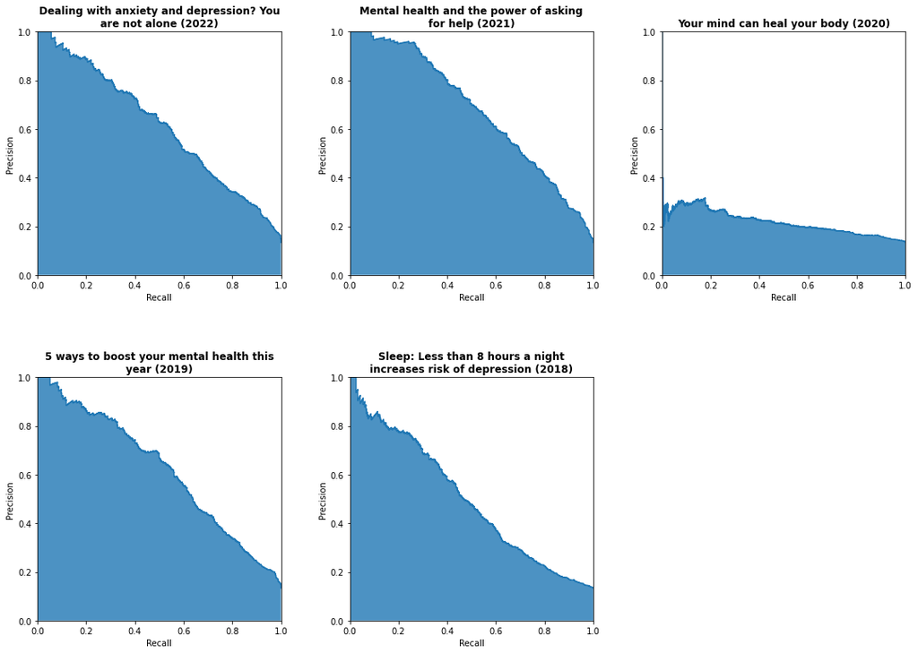

# Recommendation

Mental health is a significant factor in a person’s well-being; it can affect how one will be able to live their life. As such, the team chose to focus on creating a repository of mental health related articles from `Inquirer.net` mainly because of its relevancy today. In creating the report, the team took multiple steps from web scraping to vectorizing data from `Inquirer.net` and assessed the results of the model.

To further the team's research, the team would like to expand the year filter earlier than 2018 to really see the progression in articles over the years. Another improvement is to expand the database used such as going beyond lifestyle category, as there might be articles from other categories such as opinion, technology and others which might be correlated to mental health that have been missed. Doing this will allow the team to have a more robust database which will lead to a better result.

With the relevance of mental health currently, this report has great potential to be of help to a lot of people struggling with their mental health or just aiming to improve their quality of life.

# Appendix

- Mental Health. (2022, February 28). *What Is Mental Health?* https://www.mentalhealth.gov/basics/what-is-mental-health
- Brunier, A. (2022, March 2). *COVID-19 pandemic triggers 25% increase in prevalence of anxiety and depression worldwide.* https://www.who.int/news/item/02-03-2022-covid-19-pandemic-triggers-25-increase-in-prevalence-of-anxiety-and-depression-worldwide